# MSMB Chapter 6 – Testing

Key Concepts Explained

2026-06-30

# Task 1

# 1 Null Hypothesis and Alternative Hypothesis

## The basic idea

When we analyse data, we usually want to know whether something interesting is going on — for example, whether a gene is differentially expressed between two conditions. But “interesting” needs a reference point. That reference is the **null hypothesis**: it describes a boring, default world where nothing is happening. In the gene expression example, the null hypothesis would be that the gene’s expression is the same in both conditions.

The **alternative hypothesis** is simply everything that is not the null — so any situation where there actually *is* a difference. We never test the alternative directly. Instead, we ask: how likely are our data if the null were true? If the answer is “very unlikely”, we reject the null and accept that the alternative must hold.

## Why the alternative is true when the null fails

This works because together, null and alternative are exhaustive — they cover all possibilities. The logic is: we set up a default assumption (null), and we only abandon it when the data give us strong enough reason to. If the data are incompatible with the null (low p-value), the null gets rejected, and by exclusion, the alternative is what remains. This is not the same as proving the alternative — it just means the null is no longer a reasonable description of reality.

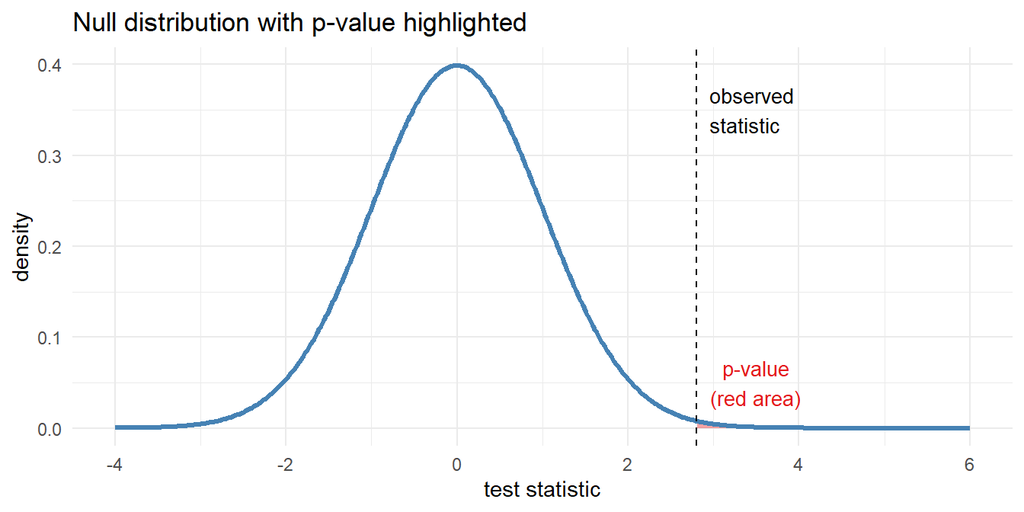

```r
# Visualise the idea: null distribution and where our observation falls
x      <- seq(-4, 6, length.out = 500)
df_viz <- tibble(
  x    = x,
  null = dnorm(x, mean = 0, sd = 1)
)

obs <- 2.8   # our test statistic

ggplot(df_viz, aes(x, null)) +
  geom_area(data = filter(df_viz, x >= obs),
            fill = "#E41A1C", alpha = 0.4) +
  geom_line(linewidth = 1.1, colour = "steelblue") +
  geom_vline(xintercept = obs, linetype = "dashed") +
  annotate("text", x = obs + 0.15, y = 0.35,
           label = "observed\nstatistic", hjust = 0, size = 3.5) +
  annotate("text", x = 3.5, y = 0.05,
           label = "p-value\n(red area)", colour = "#E41A1C", size = 3.5) +
  labs(title = "Null distribution with p-value highlighted",
       x = "test statistic", y = "density") +
  theme_minimal()
```

# 2 The p-value

## What it is

The p-value is the probability of observing a test statistic at least as extreme as the one we actually got — *assuming the null hypothesis is true*. Visually, it is the red area in the plot above: the tail of the null distribution beyond our observation.

A small p-value means our data would be very unusual in a world where the null is true. We use this as evidence against the null.

## What it is NOT

The p-value is frequently misunderstood. It is **not**:

- the probability that the null hypothesis is true
- the probability that our result occurred by chance
- a measure of effect size or biological relevance

A very large dataset can produce a tiny p-value for a biologically meaningless difference. And a large p-value does not prove the null is true — it just means we don’t have enough evidence to reject it.

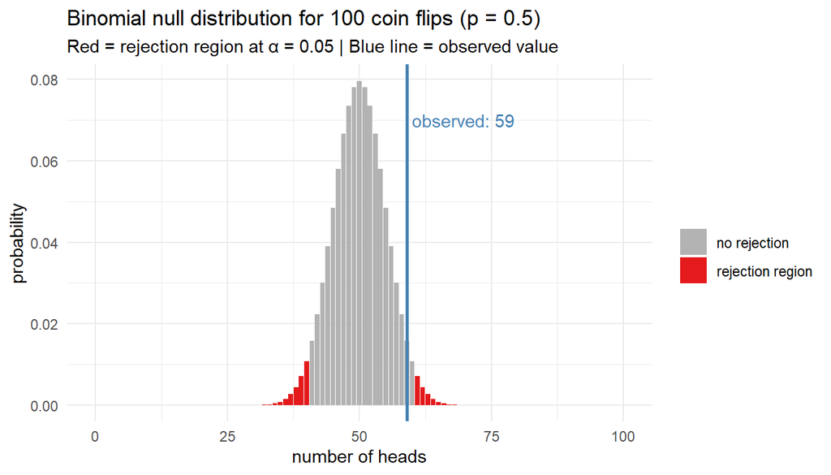

```r
# Coin tossing example from the book
set.seed(42)
numFlips <- 100
numHeads <- 59

# Null distribution: binomial with p=0.5
k             <- 0:numFlips
binomDensity  <- tibble(k = k, p = dbinom(k, size = numFlips, prob = 0.5))
alpha         <- 0.05
binomDensity  <- arrange(binomDensity, p) |>
                   mutate(reject = cumsum(p) <= alpha)

ggplot(binomDensity) +
  geom_bar(aes(x = k, y = p, fill = reject), stat = "identity") +
  scale_fill_manual(values = c("TRUE" = "#E41A1C", "FALSE" = "grey70"),
                    labels = c("TRUE" = "rejection region", "FALSE" = "no rejection")) +
  geom_vline(xintercept = numHeads, colour = "steelblue", linewidth = 1) +
  annotate("text", x = numHeads + 1, y = 0.07,
           label = paste("observed:", numHeads), hjust = 0, colour = "steelblue") +
  labs(title = "Binomial null distribution for 100 coin flips (p = 0.5)",
       subtitle = "Red = rejection region at α = 0.05 | Blue line = observed value",
       x = "number of heads", y = "probability", fill = "") +
  theme_minimal()
```

```r
# Exact p-value
pval <- binom.test(numHeads, numFlips, p = 0.5)$p.value
cat(sprintf("p-value: %.4f  →  %s reject at α = 0.05\n",
            pval, ifelse(pval < 0.05, "DO", "do NOT")))
```

```
#> p-value: 0.0886  →  do NOT reject at α = 0.05
```

# 3 Types of Error

When we make a decision based on a test, we can be right or wrong in two different ways:

|  | **Null is actually true** | **Null is actually false** |
| --- | --- | --- |
| **We reject null** | Type I error (false positive) | True positive ✓ |
| **We don’t reject** | True negative ✓ | Type II error (false negative) |

## Type I error (false positive)

We conclude there is an effect when there isn’t one. The rate at which this happens is $\alpha$, which we set ourselves (usually 0.05). This is also called the **significance level**.

## Type II error (false negative)

We miss a real effect. The rate is $\beta$. The **power** of a test is $1 - \beta$ — how often it correctly detects a true effect.

## The trade-off

You can never eliminate both errors at once. Making the test stricter (lower $\alpha$, shifting the threshold) reduces false positives but inevitably increases false negatives — and vice versa. The right balance depends on the context: missing a real drug effect (false negative) and falsely approving an ineffective drug (false positive) have very different consequences.

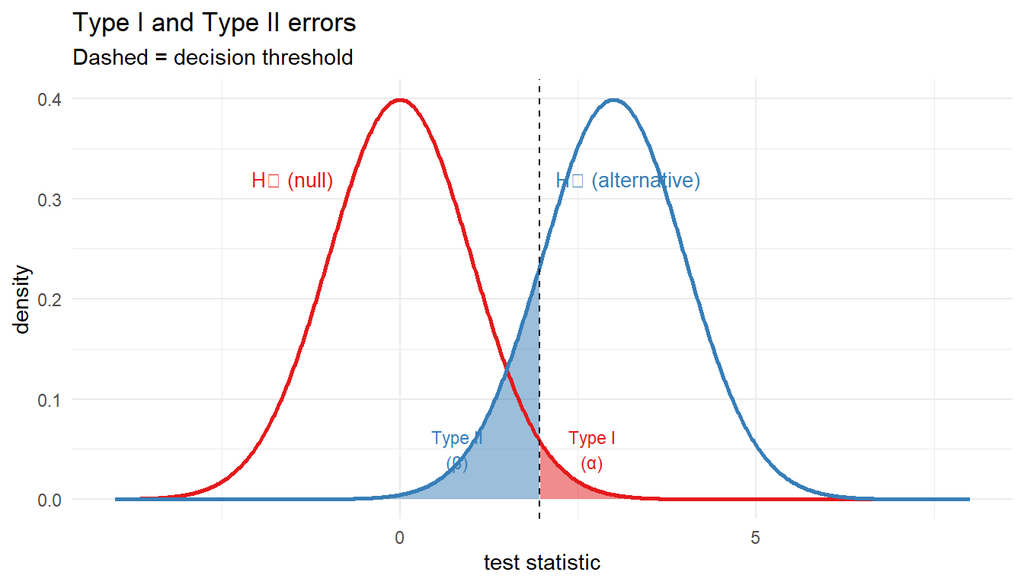

```r
x    <- seq(-4, 8, length.out = 1000)
thresh <- 1.96

df_errors <- tibble(
  x   = x,
  H0  = dnorm(x, mean = 0, sd = 1),
  H1  = dnorm(x, mean = 3, sd = 1)
)

ggplot(df_errors, aes(x)) +
  geom_area(data = filter(df_errors, x >= thresh),
            aes(y = H0), fill = "#E41A1C", alpha = 0.5) +
  geom_area(data = filter(df_errors, x <= thresh),
            aes(y = H1), fill = "#377EB8", alpha = 0.5) +
  geom_line(aes(y = H0), colour = "#E41A1C", linewidth = 1) +
  geom_line(aes(y = H1), colour = "#377EB8", linewidth = 1) +
  geom_vline(xintercept = thresh, linetype = "dashed") +
  annotate("text", x = 3.2,  y = 0.32, label = "H₁ (alternative)",
           colour = "#377EB8", size = 3.5) +
  annotate("text", x = -1.5, y = 0.32, label = "H₀ (null)",
           colour = "#E41A1C", size = 3.5) +
  annotate("text", x = 2.7,  y = 0.05, label = "Type I\n(α)",
           colour = "#E41A1C", size = 3) +
  annotate("text", x = 0.8,  y = 0.05, label = "Type II\n(β)",
           colour = "#377EB8", size = 3) +
  labs(title = "Type I and Type II errors",
       subtitle = "Dashed = decision threshold",
       x = "test statistic", y = "density") +
  theme_minimal()
```

# 4 Multiple Testing

## The problem

In biology we rarely test just one hypothesis. A typical RNA-Seq experiment tests thousands of genes simultaneously. If we use $\alpha = 0.05$ for each test, we expect $5\%$ of all tests to produce a false positive — even when nothing is truly differentially expressed. For 20,000 genes, that’s 1,000 false positives by chance alone.

The xkcd comic the book references illustrates this perfectly: if you test 20 jelly bean colours for causing acne, one of them will likely come up “significant” purely by chance — and that’s the one that gets reported in the newspaper.

## Family-wise error rate (FWER) and Bonferroni

One approach is to control the **family-wise error rate**: the probability of making *at least one* false positive across all tests. The Bonferroni correction divides $\alpha$ by the number of tests $m$:

$$\alpha_{\text{per test}} =
\frac{\alpha_{\text{FWER}}}{m}$$

This is very conservative — with 20,000 genes, each individual test needs to reach $p < 0.0000025$ to be called significant. Real effects can easily be missed.

```r
m     <- 20000
alpha <- 0.05
cat("Bonferroni threshold per test:", alpha / m, "\n")
```

```
#> Bonferroni threshold per test: 2.5e-06
```

```r
# How FWER blows up without correction
tibble(m_tests = c(1, 10, 100, 1000, 10000),
       FWER    = 1 - (1 - alpha)^m_tests) |>
  knitr::kable(digits = 4,
               col.names = c("Number of tests", "FWER (no correction)"))
```

| Number of tests | FWER (no correction) |
| --- | --- |
| 1 | 0.0500 |
| 10 | 0.4013 |
| 100 | 0.9941 |
| 1000 | 1.0000 |
| 10000 | 1.0000 |

## Multiple testing as an opportunity

The book makes an important point: multiple testing is not just a burden. When you have thousands of p-values, you can *learn from their distribution*. The histogram of p-values is itself informative — it tells you how many true effects there are and how strong they are. This is something you can never get from a single test.

# 5 False Discovery Rate

## A better question

Instead of asking “will I make any false positive at all?” (FWER), the FDR asks a more practical question: **among all the things I call significant, what fraction are actually false positives?**

$$\text{FDR} =
\mathbb{E}\!\left[\frac{\text{false positives}}{\text{all
rejections}}\right]$$

If I reject 100 hypotheses and control FDR at 10%, I accept that about 10 of those 100 are probably wrong. For a genome-wide screen where we’re going to follow up anyway, this is a completely reasonable trade-off.

## The p-value histogram

Before applying any FDR method, always plot the histogram of all p-values. It should show:

- a **peak near 0** — these are the true positives (genes with real effects)
- a **flat uniform part** — these are the true nulls (p-values from null hypotheses are uniformly distributed between 0 and 1 by definition)

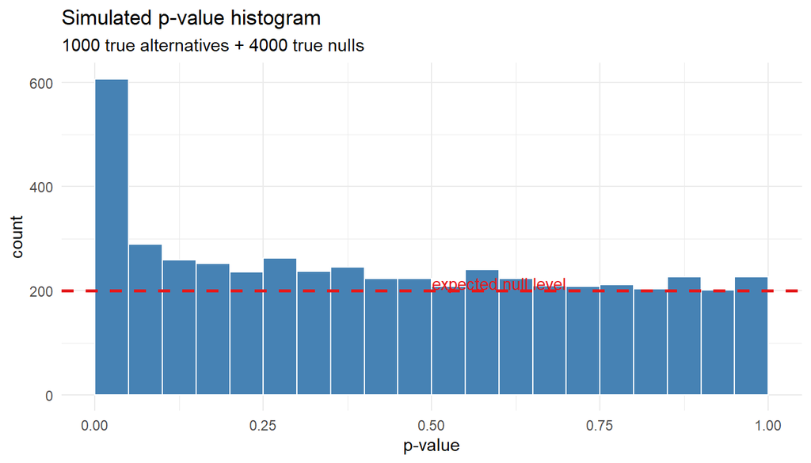

```r
set.seed(99)
m        <- 5000
m0       <- 4000   # true nulls
m1       <- m - m0 # true alternatives

p_null <- runif(m0)                        # nulls: uniform
p_alt  <- rbeta(m1, shape1 = 0.3, shape2 = 1)  # alternatives: enriched near 0

p_all  <- c(p_null, p_alt)

ggplot(tibble(p = p_all), aes(x = p)) +
  geom_histogram(binwidth = 0.05, boundary = 0,
                 fill = "steelblue", colour = "white") +
  geom_hline(yintercept = m0 * 0.05,   # expected null count per bin
             colour = "#E41A1C", linetype = "dashed", linewidth = 1) +
  annotate("text", x = 0.6, y = m0 * 0.05 + 15,
           label = "expected null level", colour = "#E41A1C", size = 3.5) +
  labs(title = "Simulated p-value histogram",
       subtitle = paste0(m1, " true alternatives + ", m0, " true nulls"),
       x = "p-value", y = "count") +
  theme_minimal()
```

## Benjamini-Hochberg procedure

The most widely used method for FDR control. The steps:

1. Sort all $m$ p-values: $p_{(1)} \leq p_{(2)} \leq \cdots \leq p_{(m)}$
2. Choose target FDR level $\varphi$ (e.g. 0.05 or 0.10)
3. Find the largest $k$ such that $p_{(k)} \leq \varphi \cdot k / m$
4. Reject all hypotheses $1, \ldots, k$

```r
phi   <- 0.10
p_sorted <- sort(p_all)
m_tot    <- length(p_sorted)
rank_vec <- seq_along(p_sorted)

# Find BH cutoff
bh_line  <- phi * rank_vec / m_tot
k_max    <- max(which(p_sorted <= bh_line))
p_cutoff <- p_sorted[k_max]

cat(sprintf("BH threshold at FDR = %.2f: p ≤ %.4f → %d rejections\n",
            phi, p_cutoff, k_max))
```

```
#> BH threshold at FDR = 0.10: p ≤ 0.0043 → 227 rejections
```

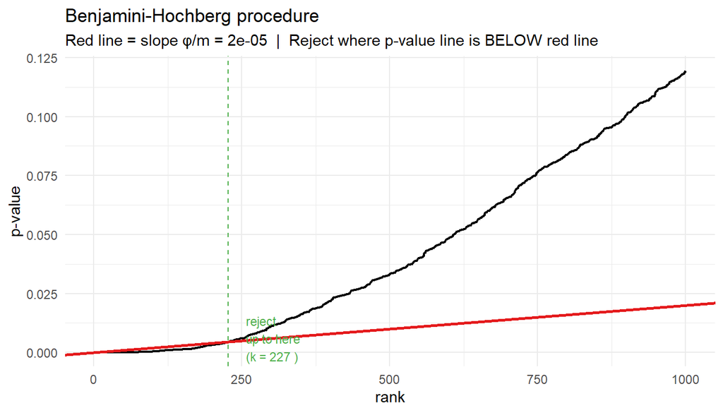

```r
# Visualise only the smallest 1000 p-values for clarity
n_show <- 1000
ggplot(tibble(rank = rank_vec[1:n_show], p = p_sorted[1:n_show]),
       aes(rank, p)) +
  geom_line(linewidth = 0.8) +
  geom_abline(slope = phi / m_tot, intercept = 0,
              colour = "#E41A1C", linewidth = 1) +
  geom_vline(xintercept = k_max, linetype = "dashed", colour = "#4DAF4A") +
  annotate("text", x = k_max + 30, y = 0.006,
           label = paste("reject\nup to here\n(k =", k_max, ")"),
           hjust = 0, colour = "#4DAF4A", size = 3) +
  labs(title = "Benjamini-Hochberg procedure",
       subtitle = paste0("Red line = slope φ/m = ", round(phi/m_tot, 6),
                         "  |  Reject where p-value line is BELOW red line"),
       x = "rank", y = "p-value") +
  theme_minimal()
```

## Correction method choice: Bonferroni vs. BH

|  | **Bonferroni** | **Benjamini-Hochberg** |
| --- | --- | --- |
| Controls | FWER (≥1 false positive) | FDR (fraction false positives) |
| How strict | Very conservative | More lenient |
| Best for | Confirmatory, few tests, high stakes | Exploratory, many tests |
| Risk | Many missed real effects | Some false positives in the hit list |

**My choice:** For a genome-wide screen (like the yeast heatshock data), BH is the right approach. We’re looking for candidates to follow up, not making final claims — a small fraction of false positives in the hit list is acceptable, and Bonferroni would throw away too many real hits.

```r
# Direct comparison on the same data
p_bonferroni <- p.adjust(p_all, method = "bonferroni")
p_bh         <- p.adjust(p_all, method = "BH")

cat("Rejections at α = 0.05:\n")
```

```
#> Rejections at α = 0.05:
```

```r
cat("  Bonferroni:", sum(p_bonferroni < 0.05), "\n")
```

```
#>   Bonferroni: 36
```

```r
cat("  BH        :", sum(p_bh         < 0.05), "\n")
```

```
#>   BH        : 168
```

```r
cat("  Truth     :", m1, "true alternatives\n")
```

```
#>   Truth     : 1000 true alternatives
```

# 6 Summary

| Concept | In one sentence |
| --- | --- |
| **Null hypothesis** | The default assumption of “nothing happening”; we test against it |
| **Alternative hypothesis** | Everything that is not the null; accepted when null is rejected |
| **p-value** | Probability of data at least this extreme *if* the null were true |
| **Type I error** | False positive — rejecting a true null (rate = α) |
| **Type II error** | False negative — missing a real effect (rate = β) |
| **Multiple testing** | Running many tests inflates false positives; needs correction |
| **Bonferroni** | Divide α by number of tests; very strict FWER control |
| **FDR** | Expected fraction of false positives among all rejections |
| **BH procedure** | Practical FDR control; sorts p-values and finds a cutoff |
| **p-value histogram** | Essential sanity check; flat = mostly nulls, peak at 0 = real signal |

# Task 2

DESeq2 is one of the standard tools for detecting differentially expressed genes from RNA-seq count data. Raw read counts are noisy and depend on sequencing depth, so DESeq2 first normalises the counts across samples (using a median-of-ratios method) to make them comparable. It then fits a negative binomial generalized linear model to the counts of each gene, because RNA-seq counts are typically overdispersed compared to a simple Poisson model — biological replicates vary more than pure counting noise would predict. To get stable variance estimates even with few replicates, DESeq2 borrows information across all genes: it shrinks each gene’s individual dispersion estimate towards a fitted trend describing how variance generally depends on mean expression. The same shrinkage idea is applied to the estimated fold changes, which keeps genes with low counts or high uncertainty from dominating downstream rankings purely due to noise.

For each gene, DESeq2 then performs a Wald test (or, for more complex designs, a likelihood ratio test) against the null hypothesis that there is no difference in expression between the two conditions being compared. Because this test is run separately for every gene — typically several thousand times per comparison — DESeq2 automatically applies a multiple testing correction (Benjamini-Hochberg by default) and reports an adjusted p-value (padj) for each gene, exactly the FDR-control approach we discussed in Task 1.

This matters biologically because differential expression is usually the entry point into understanding what a treatment or condition actually does at the molecular level. A list of genes that change significantly between conditions can point to which pathways are activated or repressed, which transcription factors might be driving the response, and which genes could be functionally important rather than just incidentally changed. In our case, comparing yeast at 25°C (baseline) to yeast under heat shock at 42°C lets us identify the transcriptional heat-shock response — for example, genes coding for chaperones that get strongly upregulated to protect proteins from heat-induced misfolding. Without a method like DESeq2 that properly accounts for both biological variability and the multiple-testing problem, such a gene list would be dominated by noise rather than real biological signal.

```r
library(tidyverse)
library(DESeq2)

raw_data <- read_csv("basic_yeast_heatshock.csv")

counts_10min <- raw_data %>% select(gene_id, `25_0_r1`, `25_0_r2`, `25_0_r3`, `42_10_r1`, `42_10_r2`, `42_10_r3`)  %>% column_to_rownames(var = "gene_id") %>% as.matrix()

col_data_10min <- data.frame(condition = factor(c("control_0min", "control_0min", "control_0min", "heat_10min",   "heat_10min",   "heat_10min")))
rownames(col_data_10min) <- colnames(counts_10min)

col_data_10min$condition <- relevel(col_data_10min$condition, ref = "control_0min") # control group as baseline

all(colnames(counts_10min) == rownames(col_data_10min))
```

```
#> [1] TRUE
```

```r
dds_10min <- DESeqDataSetFromMatrix(countData = counts_10min,
                              colData = col_data_10min,
                              design = ~ condition)

dds_10min <- DESeq(dds_10min)

result_10min <- results(dds_10min, contrast = c("condition", "heat_10min", "control_0min"))

res_10min_df <- result_10min %>% as.data.frame() %>% rownames_to_column(var = "gene_id")

head(res_10min_df)
```

```
#>    gene_id   baseMean log2FoldChange     lfcSE       stat       pvalue
#> 1 15S_rRNA   1.320728     -0.5617083 1.9273556 -0.2914399 7.707149e-01
#> 2 21S_rRNA  31.153885     -0.3425499 0.5784585 -0.5921772 5.537320e-01
#> 3     HRA1   2.319461      4.0301065 1.6374322  2.4612357 1.384594e-02
#> 4     ICR1 174.154312      0.9328264 0.2963616  3.1475955 1.646193e-03
#> 5     LSR1  17.109502     -0.4077542 0.7309784 -0.5578197 5.769675e-01
#> 6     NME1  61.650727      3.1590860 0.4387392  7.2003732 6.004799e-13
#>           padj
#> 1 8.215112e-01
#> 2 6.357203e-01
#> 3 2.764236e-02
#> 4 4.013208e-03
#> 5 6.571138e-01
#> 6 5.051435e-12
```

```r
counts_30min <- raw_data %>% select(gene_id, `25_0_r1`, `25_0_r2`, `25_0_r3`, `42_30_r1`, `42_30_r2`, `42_30_r3`) %>% column_to_rownames(var = "gene_id") %>% as.matrix()

col_data_30min <- data.frame(condition = factor(c("control_0min", "control_0min", "control_0min",
    "heat_30min",   "heat_30min",   "heat_30min")))
rownames(col_data_30min) <- colnames(counts_30min)
col_data_30min$condition <- relevel(col_data_30min$condition, ref = "control_0min")
all(colnames(counts_30min) == rownames(col_data_30min))
```

```
#> [1] TRUE
```

```r
dds_30min <- DESeqDataSetFromMatrix(countData = counts_30min,
                                    colData = col_data_30min,
                                    design = ~ condition)

dds_30min <- DESeq(dds_30min)

result_30min <- results(dds_30min, contrast = c("condition", "heat_30min", "control_0min"))
res_30min_df <- result_30min %>% as.data.frame() %>% rownames_to_column(var = "gene_id")

head(res_30min_df)
```

```
#>    gene_id   baseMean log2FoldChange     lfcSE       stat       pvalue
#> 1 15S_rRNA   1.564707      0.1198912 1.6225012  0.0738928 9.410957e-01
#> 2 21S_rRNA  44.068966      0.5734082 0.5156466  1.1120177 2.661305e-01
#> 3     HRA1   3.490507      4.6145155 1.5395874  2.9972416 2.724347e-03
#> 4     ICR1 314.952525      2.0809811 0.2673594  7.7834598 7.056761e-15
#> 5     LSR1  39.756800      1.6273470 0.5927351  2.7454877 6.042104e-03
#> 6     NME1 101.624907      3.9269901 0.3843456 10.2173405 1.658280e-24
#>           padj
#> 1 9.517479e-01
#> 2 3.213642e-01
#> 3 4.686226e-03
#> 4 2.960251e-14
#> 5 9.901062e-03
#> 6 1.088881e-23
```

```r
up_10min <- res_10min_df %>% filter(padj < 0.05 & log2FoldChange > 1)
down_10min <- res_10min_df %>% filter(padj < 0.05 & log2FoldChange < -1)

up_30min <- res_30min_df %>% filter(padj < 0.05 & log2FoldChange > 1)
down_30min <- res_30min_df %>% filter(padj < 0.05 & log2FoldChange < -1)
```

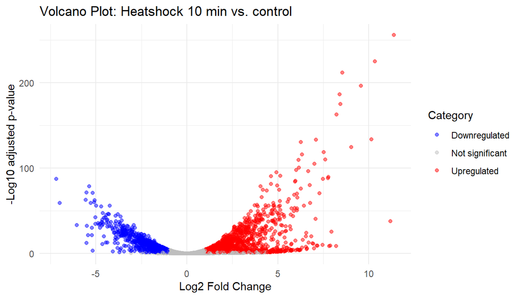

```r
plot_data_10min <- res_10min_df %>%
  mutate(Category = case_when(padj < 0.05 & log2FoldChange > 1 ~ "Upregulated",
                               padj < 0.05 & log2FoldChange < -1 ~ "Downregulated",
                               TRUE ~ "Not significant"))

ggplot(plot_data_10min, aes(x = log2FoldChange, y = -log10(padj), color = Category)) + geom_point(alpha = 0.5, size = 1.5) + scale_color_manual(values = c("Upregulated" = "red",
                                                    "Downregulated" = "blue",
                                                    "Not significant" = "grey")) +
  theme_minimal() +
  labs(title = "Volcano Plot: Heatshock 10 min vs. control", x = "Log2 Fold Change", y = "-Log10 adjusted p-value")
```

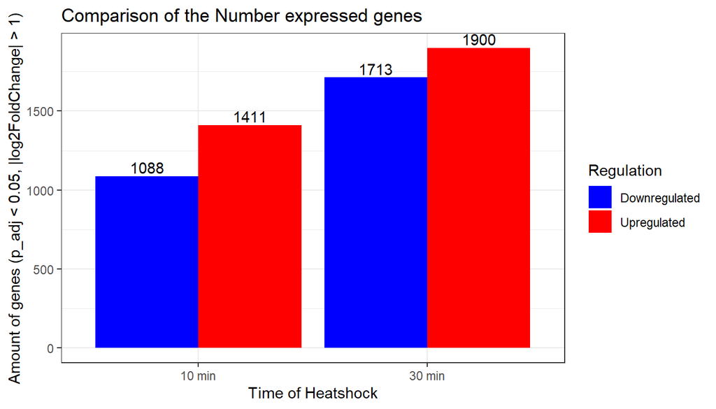

```r
data_barplot <- data.frame(Time = c("10 min", "10 min", "30 min", "30 min"),
                           Direction = c("Upregulated", "Downregulated", "Upregulated", "Downregulated"),
                           Number = c(nrow(up_10min), nrow(down_10min), nrow(up_30min), nrow(down_30min)))

ggplot(data_barplot, aes( x = Time, y = Number, fill = Direction)) + geom_bar(stat = "identity", position = "dodge") + scale_fill_manual(values = c("Upregulated" = "red", "Downregulated" = "blue")) + theme_bw() +
  labs(title = "Comparison of the Number expressed genes",
       x = "Time of Heatshock",
       y = "Amount of genes (p_adj < 0.05, |log2FoldChange| > 1)",
       fill = "Regulation") +
  geom_text(aes(label = Number), position = position_dodge(width = 0.9), vjust = -0.25)
```

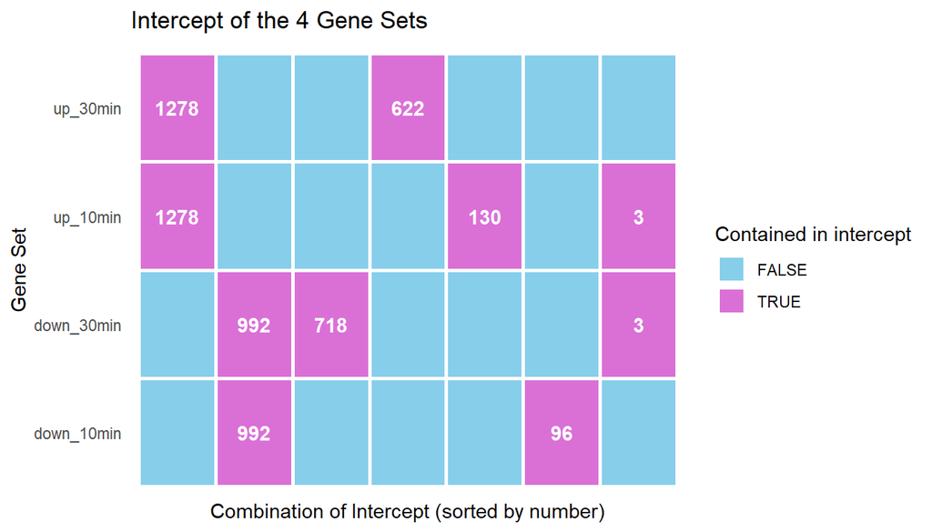

```r
u10 <- up_10min %>% select(gene_id) %>% mutate(up_10min = TRUE)
d10 <- down_10min %>% select(gene_id) %>% mutate(down_10min = TRUE)
u30 <- up_30min %>% select(gene_id) %>% mutate(up_30min = TRUE)
d30 <- down_30min %>% select(gene_id) %>% mutate(down_30min = TRUE)

overlap_matrix <- u10 %>%
  full_join(d10, by = "gene_id") %>%
  full_join(u30, by = "gene_id") %>%
  full_join(d30, by = "gene_id")

overlap_clean <- overlap_matrix %>%
  replace_na(list(up_10min = FALSE, down_10min = FALSE, up_30min = FALSE, down_30min = FALSE)) # NA -> FALSE

overlap_counts <- overlap_clean %>% dplyr::count(up_10min, down_10min, up_30min, down_30min, name = "Number_Genes")

overlap_long <- overlap_counts %>% mutate(Combination_ID = paste0("Intercept_", row_number())) %>% pivot_longer(cols = c(up_10min, down_10min, up_30min, down_30min), names_to = "Gen_Set", values_to = "is_valid")

ggplot(overlap_long, aes(x = reorder(Combination_ID, -Number_Genes), y = Gen_Set)) +
  geom_tile(aes(fill = is_valid), color = "white", size = 1) +
  scale_fill_manual(values = c("TRUE" = "orchid", "FALSE" = "skyblue")) + geom_text(aes(label = ifelse(is_valid, as.character(Number_Genes), "")), color = "white", fontface = "bold") +
  theme_minimal() +
  labs(title = "Intercept of the 4 Gene Sets",
       x = "Combination of Intercept (sorted by number)",
       y = "Gene Set",
       fill = "Contained in intercept") +
  theme(axis.text.x = element_blank(),
        panel.grid = element_blank())
```

Looking at the overlap plot, the four gene sets (up/down at 10min, up/down at 30min) are not identical, but they do share a substantial core. The largest single combination is genes that are significantly upregulated at **both** 10min and 30min (1278 genes) — these are most likely the canonical heat-shock response genes (e.g. chaperones) that get switched on quickly and stay on throughout the stress response. Similarly, 992 genes are downregulated at both time points, presumably genes related to normal growth and metabolism that get suppressed while the cell prioritises stress survival.

Overall, the overlap confirms that the heat-shock response in yeast is substantially shared between the two time points, but with meaningful time-dependent differences — exactly the kind of pattern you would expect from a regulated, multi-stage stress response rather than random noise.